# Taller3_ADD_Salazar

Andrés Salazar

2023-05-22

En el presente documento se desarrolla el taller 3 del curso de Análisis Avanzado de Datos de la maestría MACC.

## Dependencias y configuraciones

```r
rm(list = ls())
SEED <- 1

library(ggplot2)
library(gridExtra)
library(readxl)
```

# Problema 1

En este problema se muestra que las distribuciones Bernoulli, Normal y Poisson pertenecen a la familia exponencial de distribuciones. Esto se realiza llevando la función de probabilidad de cada una de estas a la forma indicada. En las siguientes imagenes el desarrollo.

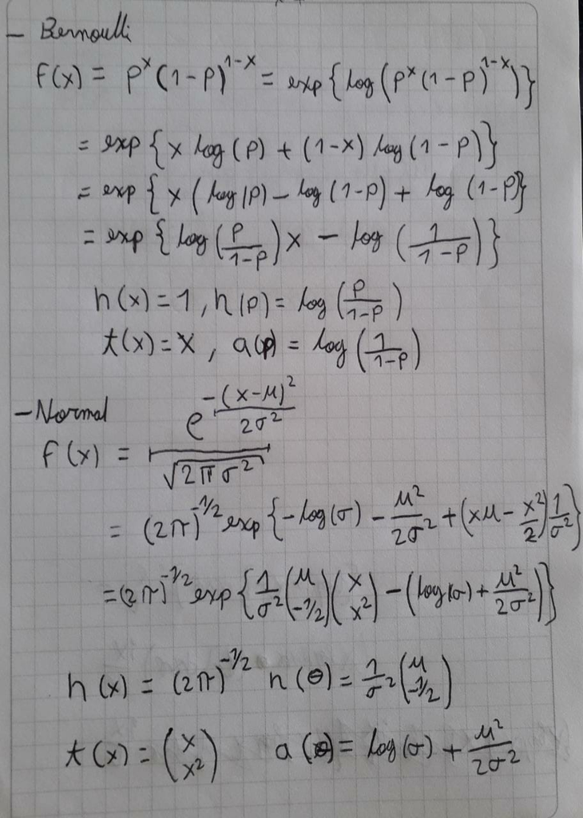

Distribuciones Bernoulli y Normal

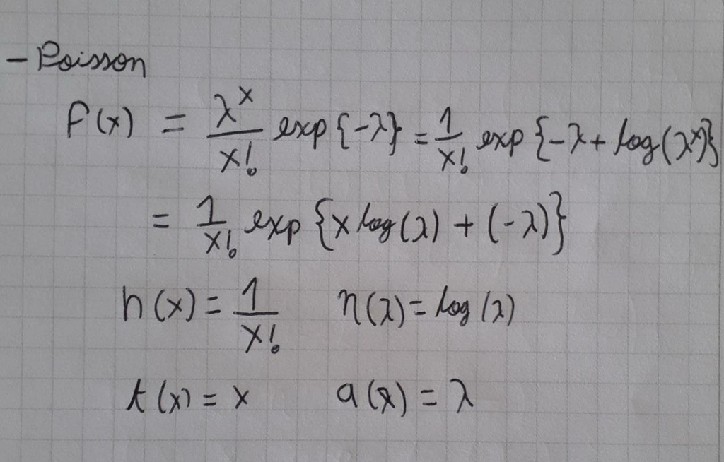

Distribución Poisson

# Poblema 2

A continuación cargamos los datos y según lo indicado en la guía de los datos unificamos todos los tipos de enfermedades cardíacas en un solo indicador.

Aquí el significado de las variables en los datos limpios:

- V1. (age)
- V2. (sex)
- V3. (cp)
- V4. (trestbps)
- V5. (chol)
- V6. (fbs)
- V7. (restecg)
- V8. (thalach)
- V9. (exang)
- V10. (oldpeak)
- V11. (slope)
- V12. (ca)
- V13 (thal)
- V14 (num) (the predicted attribute)

```r
# Load data
data <- read.table("http://archive.ics.uci.edu/ml/machine-learning-databases/heart-disease/processed.cleveland.data",
                  sep = ",")

# Categorizar variable respuesta V14, 1-4 -> 1
data$V14[data$V14 > 0] <- 1
table(data$V14)
```

```
##
##   0   1
## 164 139
```

## 1. Imputar datos con la mediana

```r
colSums(is.na(data))
```

```
##  V1  V2  V3  V4  V5  V6  V7  V8  V9 V10 V11 V12 V13 V14
##   0   0   0   0   0   0   0   0   0   0   0   0   0   0
```

```r
colSums(data == "?")
```

```
##  V1  V2  V3  V4  V5  V6  V7  V8  V9 V10 V11 V12 V13 V14
##   0   0   0   0   0   0   0   0   0   0   0   4   2   0
```

```r
data$V12[data$V12 == "?"] <- NA
data$V13[data$V13 == "?"] <- NA
data$V12<- as.integer(data$V12)
data$V13<- as.integer(data$V13)

median(data$V12, na.rm = T)
```

```
## [1] 0
```

```r
median(data$V13, na.rm = T)
```

```
## [1] 3
```

```r
# Usar la mediana para imputar
data$V12[is.na(data$V12)] <- median(data$V12, na.rm = T)
data$V13[is.na(data$V13)] <- median(data$V13, na.rm = T)
```

## Revisar las distribuciones bivariadas

```r
tapply(data, data$V14, summary)
```

```
## $`0`
##        V1              V2              V3              V4
##  Min.   :29.00   Min.   :0.000   Min.   :1.000   Min.   : 94.0
##  1st Qu.:44.75   1st Qu.:0.000   1st Qu.:2.000   1st Qu.:120.0
##  Median :52.00   Median :1.000   Median :3.000   Median :130.0
##  Mean   :52.59   Mean   :0.561   Mean   :2.793   Mean   :129.2
##  3rd Qu.:59.00   3rd Qu.:1.000   3rd Qu.:3.000   3rd Qu.:140.0
##  Max.   :76.00   Max.   :1.000   Max.   :4.000   Max.   :180.0
##        V5              V6               V7               V8
##  Min.   :126.0   Min.   :0.0000   Min.   :0.0000   Min.   : 96.0
##  1st Qu.:208.8   1st Qu.:0.0000   1st Qu.:0.0000   1st Qu.:148.8
##  Median :234.5   Median :0.0000   Median :0.0000   Median :161.0
##  Mean   :242.6   Mean   :0.1402   Mean   :0.8354   Mean   :158.4
##  3rd Qu.:267.2   3rd Qu.:0.0000   3rd Qu.:2.0000   3rd Qu.:172.0
##  Max.   :564.0   Max.   :1.0000   Max.   :2.0000   Max.   :202.0
##        V9              V10              V11             V12
##  Min.   :0.0000   Min.   :0.0000   Min.   :1.000   Min.   :0.0000
##  1st Qu.:0.0000   1st Qu.:0.0000   1st Qu.:1.000   1st Qu.:0.0000
##  Median :0.0000   Median :0.2000   Median :1.000   Median :0.0000
##  Mean   :0.1402   Mean   :0.5866   Mean   :1.409   Mean   :0.2683
##  3rd Qu.:0.0000   3rd Qu.:1.0250   3rd Qu.:2.000   3rd Qu.:0.0000
##  Max.   :1.0000   Max.   :4.2000   Max.   :3.000   Max.   :3.0000
##       V13             V14
##  Min.   :3.000   Min.   :0
##  1st Qu.:3.000   1st Qu.:0
##  Median :3.000   Median :0
##  Mean   :3.793   Mean   :0
##  3rd Qu.:3.000   3rd Qu.:0
##  Max.   :7.000   Max.   :0
##
## $`1`
##        V1              V2               V3             V4
##  Min.   :35.00   Min.   :0.0000   Min.   :1.00   Min.   :100.0
##  1st Qu.:52.00   1st Qu.:1.0000   1st Qu.:4.00   1st Qu.:120.0
##  Median :58.00   Median :1.0000   Median :4.00   Median :130.0
##  Mean   :56.63   Mean   :0.8201   Mean   :3.59   Mean   :134.6
##  3rd Qu.:62.00   3rd Qu.:1.0000   3rd Qu.:4.00   3rd Qu.:145.0
##  Max.   :77.00   Max.   :1.0000   Max.   :4.00   Max.   :200.0
##        V5              V6               V7              V8
##  Min.   :131.0   Min.   :0.0000   Min.   :0.000   Min.   : 71.0
##  1st Qu.:217.5   1st Qu.:0.0000   1st Qu.:0.000   1st Qu.:125.0
##  Median :249.0   Median :0.0000   Median :2.000   Median :142.0
##  Mean   :251.5   Mean   :0.1583   Mean   :1.173   Mean   :139.3
##  3rd Qu.:283.5   3rd Qu.:0.0000   3rd Qu.:2.000   3rd Qu.:156.5
##  Max.   :409.0   Max.   :1.0000   Max.   :2.000   Max.   :195.0
##        V9              V10             V11             V12
##  Min.   :0.0000   Min.   :0.000   Min.   :1.000   Min.   :0.000
##  1st Qu.:0.0000   1st Qu.:0.550   1st Qu.:1.000   1st Qu.:0.000
##  Median :1.0000   Median :1.400   Median :2.000   Median :1.000
##  Mean   :0.5468   Mean   :1.574   Mean   :1.827   Mean   :1.129
##  3rd Qu.:1.0000   3rd Qu.:2.500   3rd Qu.:2.000   3rd Qu.:2.000
##  Max.   :1.0000   Max.   :6.200   Max.   :3.000   Max.   :3.000
##       V13            V14
##  Min.   :3.00   Min.   :1
##  1st Qu.:3.00   1st Qu.:1
##  Median :7.00   Median :1
##  Mean   :5.82   Mean   :1
##  3rd Qu.:7.00   3rd Qu.:1
##  Max.   :7.00   Max.   :1
```

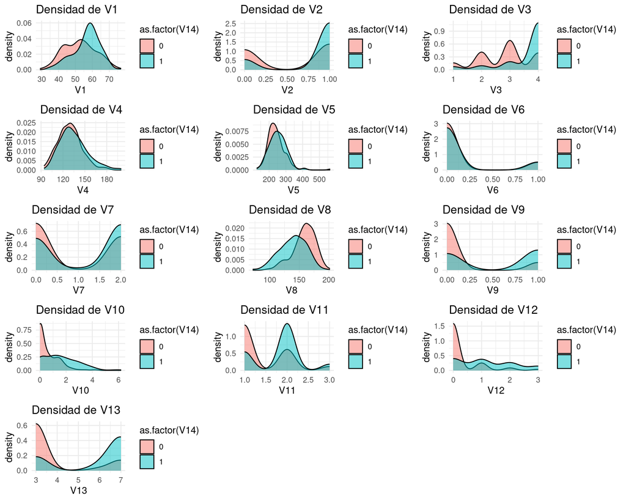

```r
# Crear una lista de nombres de variables (excepto V14)
variable_names <- names(data)[-which(names(data) == "V14")]

# Crear una función para generar gráficos de densidad
plot_density <- function(variable) {
  ggplot(data, aes(x = .data[[variable]], fill = as.factor(V14))) +
    geom_density(alpha = 0.5) + xlab(variable) +
    labs(title = paste("Densidad de", variable)) +
    theme_minimal()
}

# Crear subgráficos para cada variable
plots <- lapply(variable_names, plot_density)

# Mostrar los gráficos en una cuadrícula
grid.arrange(grobs = plots, ncol = 3)
```

Estos resultados nos permiten ver que hay variables en las cuales la distribución entre los individuos con enfermedades y sin enfermedades en muy similar y podrían no aportar a la predicció, como V5 (chol). Pero al contrario, hay variables en las que se encuentra gran oportunidad a tener una distribución notablemente diferente, como lo es V3 (cp).

```r
print("Tabla de contingencia")
```

```
## [1] "Tabla de contingencia"
```

```r
table(data$V6, data$V14)
```

```
##
##       0   1
##   0 141 117
##   1  23  22
```

```r
#Estimación manual
tabla_contingencia <- table(data$V6, data$V14)
proporciones <- prop.table(tabla_contingencia, margin = 1)
difflog_prop <- diff(log(proporciones))
betas <- cumsum(difflog_prop)

print("Coeficientes")
```

```
## [1] "Coeficientes"
```

```r
betas
```

```
## [1] -0.066968579  0.008197034
```

Comparemos con el modelo usando GLM

```r
model_rl <- glm(V14~V6, family="binomial", data=data)
summary(model_rl)
```

```
##
## Call:
## glm(formula = V14 ~ V6, family = "binomial", data = data)
##
## Coefficients:
##             Estimate Std. Error z value Pr(>|z|)
## (Intercept)  -0.1866     0.1251  -1.492    0.136
## V6            0.1421     0.3234   0.440    0.660
##
## (Dispersion parameter for binomial family taken to be 1)
##
##     Null deviance: 417.98  on 302  degrees of freedom
## Residual deviance: 417.79  on 301  degrees of freedom
## AIC: 421.79
##
## Number of Fisher Scoring iterations: 3
```

Vemos que hay una notable diferencia en el beta estimado, que puede deberse al uso de máxima verosimilitud que tiene en cuenta la distribución conjunta de V6 y V14, o también al efecto de la regularización de loa coeficiente.

## Modelo multivariado

```r
model_rl <- glm(V14~., family="binomial", data=data)
summary(model_rl)
```

```
##
## Call:
## glm(formula = V14 ~ ., family = "binomial", data = data)
##
## Coefficients:
##              Estimate Std. Error z value Pr(>|z|)
## (Intercept) -7.551087   2.857180  -2.643 0.008221 **
## V1          -0.014491   0.023877  -0.607 0.543921
## V2           1.371145   0.488398   2.807 0.004994 **
## V3           0.611789   0.190567   3.210 0.001326 **
## V4           0.023837   0.010710   2.226 0.026028 *
## V5           0.005030   0.003767   1.335 0.181740
## V6          -0.777545   0.529833  -1.468 0.142232
## V7           0.235034   0.182607   1.287 0.198059
## V8          -0.020028   0.010158  -1.972 0.048651 *
## V9           1.032238   0.409469   2.521 0.011705 *
## V10          0.243988   0.210239   1.161 0.245835
## V11          0.591238   0.359671   1.644 0.100211
## V12          1.237096   0.262772   4.708  2.5e-06 ***
## V13          0.324359   0.098555   3.291 0.000998 ***
## ---
## Signif. codes:  0 '***' 0.001 '**' 0.01 '*' 0.05 '.' 0.1 ' ' 1
##
## (Dispersion parameter for binomial family taken to be 1)
##
##     Null deviance: 417.98  on 302  degrees of freedom
## Residual deviance: 209.02  on 289  degrees of freedom
## AIC: 237.02
##
## Number of Fisher Scoring iterations: 6
```

Al estimar la regresión logística con todas las variables vemos que el procedimiento nos retorna el test de Wald en el z-score de cada coeficiente. Luego tomando la regla empírica, definimos que los parámetros con z-score mayoes a 2 en valor absoluto son significativos. Así, sabemos que las variable significativas para detecta enfermedades cardíacas son: V2, V3, V4, V9, V12 y V13.

## Predicción de probabilidades

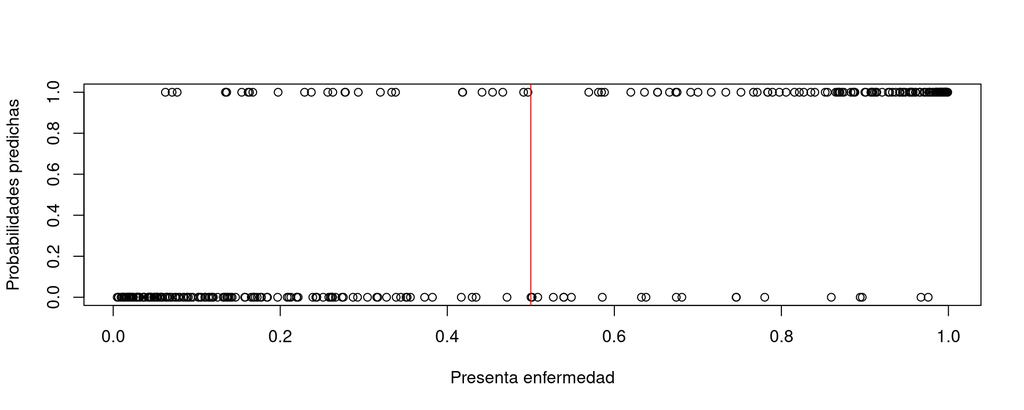

```r
pred_rl <- predict(model_rl, data, type = "response")

plot(pred_rl, data$V14,
     ylab = 'Probabilidades predichas',
     xlab = 'Presenta enfermedad')
abline(v=0.5, col="red")
```

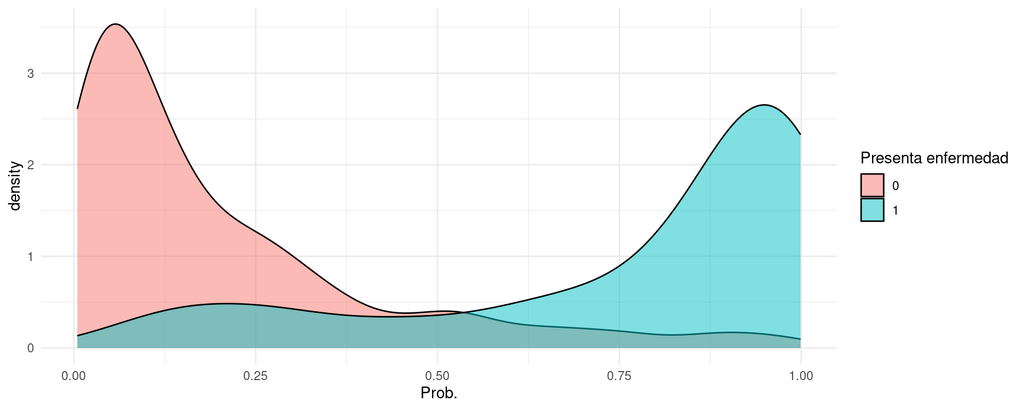

```r
ggplot(data, aes(x = pred_rl, fill = as.factor(V14))) +
  geom_density(alpha = 0.5) + xlab("Prob.") +
  theme_minimal() + guides(fill=guide_legend(title="Presenta enfermedad"))
```

El modelo describe la presencia de enfermedad cardíaca ya que como se ve en las imagenes este exibe una clara separación de las probabilidades para individuos con y sin enfermedades cardíacas, mostrando como altas probabilidades se acumulan para individuos con enfermedades y viceversa

# Problema 3

```r
data_tc <- read_excel("AAD-taller03.xlsx",
                           sheet = "Sheet1")

table(data_tc$Incumplimiento)
```

```
##
##    0    1
## 4450 4630
```

```r
summary(data_tc$ScoreLogisticoA)
```

```
##      Min.   1st Qu.    Median      Mean   3rd Qu.      Max.
## 0.0005015 0.0049170 0.0106443 0.0139798 0.0188284 0.1379898
```

```r
summary(data_tc$ScoreLogisticoB)
```

```
##    Min. 1st Qu.  Median    Mean 3rd Qu.    Max.
##  0.0100  0.1100  0.1800  0.1558  0.2100  0.2400
```

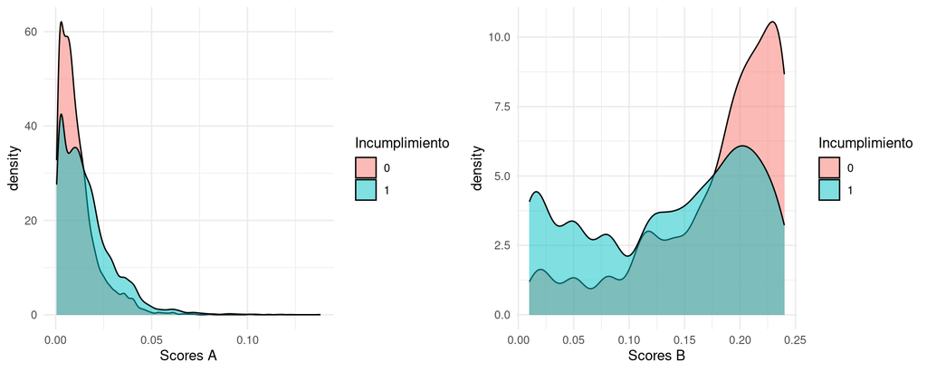

```r
plota <- ggplot(data_tc, aes(x = ScoreLogisticoA, fill = as.factor(Incumplimiento))) +
  geom_density(alpha = 0.5) + xlab("Scores A") +
  theme_minimal() + guides(fill=guide_legend(title="Incumplimiento"))
plotb <- ggplot(data_tc, aes(x = ScoreLogisticoB, fill = as.factor(Incumplimiento))) +
  geom_density(alpha = 0.5) + xlab("Scores B") +
  theme_minimal() + guides(fill=guide_legend(title="Incumplimiento"))
grid.arrange(plota, plotb, ncol=2)
```

El modelo B tiene mayor proder de predicción ya da cuenta mejor de la distribución de los datos y los score muestran una mejor separación según se da o no e incumplimiento. Vemos que hay una mayor proporción de clientes en incumplimiento, pero en el modelo A los scores se concentran en niveles bajos, tanto en los datos en que no hubo incunplimiento, como en los que si hubo.